# **Classification Project - Hotel Booking Cancellation Prediction**

# **Objective**

The increasing number of cancellations calls for a Machine Learning based solution that can help in predicting which booking is likely to be canceled. INN Hotels Group has a chain of hotels in Portugal, they are facing problems with the high number of booking cancellations and have reached out to your firm for data-driven solutions. Here, we are going to analyze the data provided to find which factors have a high influence on booking cancellations, build a predictive model that can predict which booking is going to be canceled in advance, and help in formulating profitable policies for cancellations and refunds.

# **Data Dictionary**

- Booking_ID: The unique identifier of each booking
- no_of_adults: The number of adults
- no_of_children: The number of children
- no_of_weekend_nights: The number of weekend nights (Saturday and Sunday) the guest stayed or booked to stay at the hotel
- no_of_week_nights: The number of weeknights (Monday to Friday) the guest stayed or booked to stay at the hotel
- type_of_meal_plan: The type of meal plan booked by the customer: Not Selected (No meal plan selected). Meal Plan 1 (Breakfast). Meal Plan 2 (Half board - breakfast and one other meal). Meal Plan 3 (Full board - breakfast, lunch, and dinner)
- required_car_parking_space: Does the customer require a car parking space? (0 - No, 1- Yes)
- room_type_reserved: The type of room reserved by the customer. The values are ciphered (encoded) by INN Hotels.
- lead_time: The number of days between the date of booking and the arrival date
- arrival_year: The year of arrival date
- arrival_month: The month of arrival date
- arrival_date: The date of the month
- market_segment_type: Market segment designation.
- repeated_guest: Is the customer a repeated guest? (0 - No, 1- Yes)
- no_of_previous_cancellations: The number of previous bookings that were canceled by the customer before the current booking
- no_of_previous_bookings_not_canceled: The number of previous bookings not canceled by the customer before the current booking
- avg_price_per_room: The average price per day for the reservation; prices of the rooms are dynamic. (in euros)
- no_of_special_requests: The total number of special requests made by the customer (e.g. high floor, view from the room, etc.)
- booking_status: Flag indicating if the booking was canceled or not. The class 0 represents the Not_Canceled whereas class 1 represents the Canceled label.

```python
#Importing Libraries for data manipulation and visualization

import pandas as pd

import numpy as np

import matplotlib.pyplot as plt

import seaborn as sns

from sklearn.model_selection import train_test_split

import warnings
warnings.filterwarnings("ignore")
```

```python
#Loading the data

df = pd.read_csv("/content/INNHotelsGroup (1).csv")
```

```python
#Initial data preview

df.head()
```

|  | Booking_ID | no_of_adults | no_of_children | no_of_weekend_nights | no_of_week_nights | type_of_meal_plan | required_car_parking_space | room_type_reserved | lead_time | arrival_year | arrival_month | arrival_date | market_segment_type | repeated_guest | no_of_previous_cancellations | no_of_previous_bookings_not_canceled | avg_price_per_room | no_of_special_requests | booking_status |
| --- | --- | --- | --- | --- | --- | --- | --- | --- | --- | --- | --- | --- | --- | --- | --- | --- | --- | --- | --- |
| 0 | INN00001 | 2 | 0 | 1 | 2 | Meal Plan 1 | 0 | Room_Type 1 | 224 | 2017 | 10 | 2 | Offline | 0 | 0 | 0 | 65.00 | 0 | Not_Canceled |
| 1 | INN00002 | 2 | 0 | 2 | 3 | Not Selected | 0 | Room_Type 1 | 5 | 2018 | 11 | 6 | Online | 0 | 0 | 0 | 106.68 | 1 | Not_Canceled |
| 2 | INN00003 | 1 | 0 | 2 | 1 | Meal Plan 1 | 0 | Room_Type 1 | 1 | 2018 | 2 | 28 | Online | 0 | 0 | 0 | 60.00 | 0 | Canceled |
| 3 | INN00004 | 2 | 0 | 0 | 2 | Meal Plan 1 | 0 | Room_Type 1 | 211 | 2018 | 5 | 20 | Online | 0 | 0 | 0 | 100.00 | 0 | Canceled |
| 4 | INN00005 | 2 | 0 | 1 | 1 | Not Selected | 0 | Room_Type 1 | 48 | 2018 | 4 | 11 | Online | 0 | 0 | 0 | 94.50 | 0 | Canceled |

```python
#Checking the info on the data

df.info()
```

```
<class 'pandas.core.frame.DataFrame'>
RangeIndex: 36275 entries, 0 to 36274
Data columns (total 19 columns):
 #   Column                                Non-Null Count  Dtype
---  ------                                --------------  -----
 0   Booking_ID                            36275 non-null  object
 1   no_of_adults                          36275 non-null  int64
 2   no_of_children                        36275 non-null  int64
 3   no_of_weekend_nights                  36275 non-null  int64
 4   no_of_week_nights                     36275 non-null  int64
 5   type_of_meal_plan                     36275 non-null  object
 6   required_car_parking_space            36275 non-null  int64
 7   room_type_reserved                    36275 non-null  object
 8   lead_time                             36275 non-null  int64
 9   arrival_year                          36275 non-null  int64
 10  arrival_month                         36275 non-null  int64
 11  arrival_date                          36275 non-null  int64
 12  market_segment_type                   36275 non-null  object
 13  repeated_guest                        36275 non-null  int64
 14  no_of_previous_cancellations          36275 non-null  int64
 15  no_of_previous_bookings_not_canceled  36275 non-null  int64
 16  avg_price_per_room                    36275 non-null  float64
 17  no_of_special_requests                36275 non-null  int64
 18  booking_status                        36275 non-null  object
dtypes: float64(1), int64(13), object(5)
memory usage: 5.3+ MB
```

```python
df.isnull().sum()
```

|  | 0 |
| --- | --- |
| Booking_ID | 0 |
| no_of_adults | 0 |
| no_of_children | 0 |
| no_of_weekend_nights | 0 |
| no_of_week_nights | 0 |
| type_of_meal_plan | 0 |
| required_car_parking_space | 0 |
| room_type_reserved | 0 |
| lead_time | 0 |
| arrival_year | 0 |
| arrival_month | 0 |
| arrival_date | 0 |
| market_segment_type | 0 |
| repeated_guest | 0 |
| no_of_previous_cancellations | 0 |
| no_of_previous_bookings_not_canceled | 0 |
| avg_price_per_room | 0 |
| no_of_special_requests | 0 |
| booking_status | 0 |

**dtype:** int64

```python
#Checking the summary of the data

df.describe(include='all').T
```

|  | count | unique | top | freq | mean | std | min | 25% | 50% | 75% | max |
| --- | --- | --- | --- | --- | --- | --- | --- | --- | --- | --- | --- |
| Booking_ID | 36275 | 36275 | INN36275 | 1 | NaN | NaN | NaN | NaN | NaN | NaN | NaN |
| no_of_adults | 36275.0 | NaN | NaN | NaN | 1.844962 | 0.518715 | 0.0 | 2.0 | 2.0 | 2.0 | 4.0 |
| no_of_children | 36275.0 | NaN | NaN | NaN | 0.105279 | 0.402648 | 0.0 | 0.0 | 0.0 | 0.0 | 10.0 |
| no_of_weekend_nights | 36275.0 | NaN | NaN | NaN | 0.810724 | 0.870644 | 0.0 | 0.0 | 1.0 | 2.0 | 7.0 |
| no_of_week_nights | 36275.0 | NaN | NaN | NaN | 2.2043 | 1.410905 | 0.0 | 1.0 | 2.0 | 3.0 | 17.0 |
| type_of_meal_plan | 36275 | 4 | Meal Plan 1 | 27835 | NaN | NaN | NaN | NaN | NaN | NaN | NaN |
| required_car_parking_space | 36275.0 | NaN | NaN | NaN | 0.030986 | 0.173281 | 0.0 | 0.0 | 0.0 | 0.0 | 1.0 |
| room_type_reserved | 36275 | 7 | Room_Type 1 | 28130 | NaN | NaN | NaN | NaN | NaN | NaN | NaN |
| lead_time | 36275.0 | NaN | NaN | NaN | 85.232557 | 85.930817 | 0.0 | 17.0 | 57.0 | 126.0 | 443.0 |
| arrival_year | 36275.0 | NaN | NaN | NaN | 2017.820427 | 0.383836 | 2017.0 | 2018.0 | 2018.0 | 2018.0 | 2018.0 |
| arrival_month | 36275.0 | NaN | NaN | NaN | 7.423653 | 3.069894 | 1.0 | 5.0 | 8.0 | 10.0 | 12.0 |
| arrival_date | 36275.0 | NaN | NaN | NaN | 15.596995 | 8.740447 | 1.0 | 8.0 | 16.0 | 23.0 | 31.0 |
| market_segment_type | 36275 | 5 | Online | 23214 | NaN | NaN | NaN | NaN | NaN | NaN | NaN |
| repeated_guest | 36275.0 | NaN | NaN | NaN | 0.025637 | 0.158053 | 0.0 | 0.0 | 0.0 | 0.0 | 1.0 |
| no_of_previous_cancellations | 36275.0 | NaN | NaN | NaN | 0.023349 | 0.368331 | 0.0 | 0.0 | 0.0 | 0.0 | 13.0 |
| no_of_previous_bookings_not_canceled | 36275.0 | NaN | NaN | NaN | 0.153411 | 1.754171 | 0.0 | 0.0 | 0.0 | 0.0 | 58.0 |
| avg_price_per_room | 36275.0 | NaN | NaN | NaN | 103.423539 | 35.089424 | 0.0 | 80.3 | 99.45 | 120.0 | 540.0 |
| no_of_special_requests | 36275.0 | NaN | NaN | NaN | 0.619655 | 0.786236 | 0.0 | 0.0 | 0.0 | 1.0 | 5.0 |
| booking_status | 36275 | 2 | Not_Canceled | 24390 | NaN | NaN | NaN | NaN | NaN | NaN | NaN |

### **Observations:**

The dataset has 36275 rows and 19 columns and there are no missing values. Our target variable is a categorical variable, thus, this will be a classification analysis. We have 5 categorical variables on the dataset and all the other ones are numerical variables. We can see above that Booking_ID has 36275 unique values, therefore this variables may not add much value to the model.

```python
#Dropping Booking_ID column

df = df.drop('Booking_ID', axis=1)
```

```python
df.head()
```

|  | no_of_adults | no_of_children | no_of_weekend_nights | no_of_week_nights | type_of_meal_plan | required_car_parking_space | room_type_reserved | lead_time | arrival_year | arrival_month | arrival_date | market_segment_type | repeated_guest | no_of_previous_cancellations | no_of_previous_bookings_not_canceled | avg_price_per_room | no_of_special_requests | booking_status |
| --- | --- | --- | --- | --- | --- | --- | --- | --- | --- | --- | --- | --- | --- | --- | --- | --- | --- | --- |
| 0 | 2 | 0 | 1 | 2 | Meal Plan 1 | 0 | Room_Type 1 | 224 | 2017 | 10 | 2 | Offline | 0 | 0 | 0 | 65.00 | 0 | Not_Canceled |
| 1 | 2 | 0 | 2 | 3 | Not Selected | 0 | Room_Type 1 | 5 | 2018 | 11 | 6 | Online | 0 | 0 | 0 | 106.68 | 1 | Not_Canceled |
| 2 | 1 | 0 | 2 | 1 | Meal Plan 1 | 0 | Room_Type 1 | 1 | 2018 | 2 | 28 | Online | 0 | 0 | 0 | 60.00 | 0 | Canceled |
| 3 | 2 | 0 | 0 | 2 | Meal Plan 1 | 0 | Room_Type 1 | 211 | 2018 | 5 | 20 | Online | 0 | 0 | 0 | 100.00 | 0 | Canceled |
| 4 | 2 | 0 | 1 | 1 | Not Selected | 0 | Room_Type 1 | 48 | 2018 | 4 | 11 | Online | 0 | 0 | 0 | 94.50 | 0 | Canceled |

# **Exploratory Data Analysis**

```python
#Summary statistics of our data

df.describe().T
```

|  | count | mean | std | min | 25% | 50% | 75% | max |
| --- | --- | --- | --- | --- | --- | --- | --- | --- |
| no_of_adults | 36275.0 | 1.844962 | 0.518715 | 0.0 | 2.0 | 2.00 | 2.0 | 4.0 |
| no_of_children | 36275.0 | 0.105279 | 0.402648 | 0.0 | 0.0 | 0.00 | 0.0 | 10.0 |
| no_of_weekend_nights | 36275.0 | 0.810724 | 0.870644 | 0.0 | 0.0 | 1.00 | 2.0 | 7.0 |
| no_of_week_nights | 36275.0 | 2.204300 | 1.410905 | 0.0 | 1.0 | 2.00 | 3.0 | 17.0 |
| required_car_parking_space | 36275.0 | 0.030986 | 0.173281 | 0.0 | 0.0 | 0.00 | 0.0 | 1.0 |
| lead_time | 36275.0 | 85.232557 | 85.930817 | 0.0 | 17.0 | 57.00 | 126.0 | 443.0 |
| arrival_year | 36275.0 | 2017.820427 | 0.383836 | 2017.0 | 2018.0 | 2018.00 | 2018.0 | 2018.0 |
| arrival_month | 36275.0 | 7.423653 | 3.069894 | 1.0 | 5.0 | 8.00 | 10.0 | 12.0 |
| arrival_date | 36275.0 | 15.596995 | 8.740447 | 1.0 | 8.0 | 16.00 | 23.0 | 31.0 |
| repeated_guest | 36275.0 | 0.025637 | 0.158053 | 0.0 | 0.0 | 0.00 | 0.0 | 1.0 |
| no_of_previous_cancellations | 36275.0 | 0.023349 | 0.368331 | 0.0 | 0.0 | 0.00 | 0.0 | 13.0 |
| no_of_previous_bookings_not_canceled | 36275.0 | 0.153411 | 1.754171 | 0.0 | 0.0 | 0.00 | 0.0 | 58.0 |
| avg_price_per_room | 36275.0 | 103.423539 | 35.089424 | 0.0 | 80.3 | 99.45 | 120.0 | 540.0 |
| no_of_special_requests | 36275.0 | 0.619655 | 0.786236 | 0.0 | 0.0 | 0.00 | 1.0 | 5.0 |

### **Observations:**

- The number of adults vary from no adults to maximum of 4 adults, with a mean of approximately 2 adults, which is reasonable when booking a hotel room.
- Most of the bookings have no children included. The maximum value of 10 children looks a bit odd and should be further investigated.
- Number of weekend nights range from 0 weekend nights to 7 weekend nights and number of week nights range from 0 week nights to 17 week nights, which may indicate longer stays.
- Normally customers do not require a parking space and when they do they will require one spot at most.
- Lead time refers to the number of days between the day a guest books a reservation and their scheduled check-in date. The mean lead time is 85 days, and the maximum lead time demonstrates that some bookings were made over a year in advance.
- The average price per room varies from 0, which is interesting, it may indicate a cortesy booking to 540 for more luxury rooms.

```python
#Checking the bookings when the average price per room is zero

df[df['avg_price_per_room'] == 0]
```

|  | no_of_adults | no_of_children | no_of_weekend_nights | no_of_week_nights | type_of_meal_plan | required_car_parking_space | room_type_reserved | lead_time | arrival_year | arrival_month | arrival_date | market_segment_type | repeated_guest | no_of_previous_cancellations | no_of_previous_bookings_not_canceled | avg_price_per_room | no_of_special_requests | booking_status |
| --- | --- | --- | --- | --- | --- | --- | --- | --- | --- | --- | --- | --- | --- | --- | --- | --- | --- | --- |
| 63 | 1 | 0 | 0 | 1 | Meal Plan 1 | 0 | Room_Type 1 | 2 | 2017 | 9 | 10 | Complementary | 0 | 0 | 0 | 0.0 | 1 | Not_Canceled |
| 145 | 1 | 0 | 0 | 2 | Meal Plan 1 | 0 | Room_Type 1 | 13 | 2018 | 6 | 1 | Complementary | 1 | 3 | 5 | 0.0 | 1 | Not_Canceled |
| 209 | 1 | 0 | 0 | 0 | Meal Plan 1 | 0 | Room_Type 1 | 4 | 2018 | 2 | 27 | Complementary | 0 | 0 | 0 | 0.0 | 1 | Not_Canceled |
| 266 | 1 | 0 | 0 | 2 | Meal Plan 1 | 0 | Room_Type 1 | 1 | 2017 | 8 | 12 | Complementary | 1 | 0 | 1 | 0.0 | 1 | Not_Canceled |
| 267 | 1 | 0 | 2 | 1 | Meal Plan 1 | 0 | Room_Type 1 | 4 | 2017 | 8 | 23 | Complementary | 0 | 0 | 0 | 0.0 | 1 | Not_Canceled |
| ... | ... | ... | ... | ... | ... | ... | ... | ... | ... | ... | ... | ... | ... | ... | ... | ... | ... | ... |
| 35983 | 1 | 0 | 0 | 1 | Meal Plan 1 | 0 | Room_Type 7 | 0 | 2018 | 6 | 7 | Complementary | 1 | 4 | 17 | 0.0 | 1 | Not_Canceled |
| 36080 | 1 | 0 | 1 | 1 | Meal Plan 1 | 0 | Room_Type 7 | 0 | 2018 | 3 | 21 | Complementary | 1 | 3 | 15 | 0.0 | 1 | Not_Canceled |
| 36114 | 1 | 0 | 0 | 1 | Meal Plan 1 | 0 | Room_Type 1 | 1 | 2018 | 3 | 2 | Online | 0 | 0 | 0 | 0.0 | 0 | Not_Canceled |
| 36217 | 2 | 0 | 2 | 1 | Meal Plan 1 | 0 | Room_Type 2 | 3 | 2017 | 8 | 9 | Online | 0 | 0 | 0 | 0.0 | 2 | Not_Canceled |
| 36250 | 1 | 0 | 0 | 2 | Meal Plan 2 | 0 | Room_Type 1 | 6 | 2017 | 12 | 10 | Online | 0 | 0 | 0 | 0.0 | 0 | Not_Canceled |

545 rows × 18 columns

```python
#Let's check the bookings with an average price of zero and their respective market segments.

df[df['avg_price_per_room'] == 0]['market_segment_type'].value_counts()
```

| market_segment_type | count |
| --- | --- |
| Complementary | 354 |
| Online | 191 |

**dtype:** int64

### **Observations:**

When looking at the bookings with an average booking price of zero, we can see that many of them are complementary bookings, per the market_segment_type feature. There are some bookings with no cost that the market segment is online, which may be part of some promotional campaign or loyalty rewards done by the hotel.

```python
#Let's check the distributions on our numerical columns

num_cols = df.select_dtypes(include='number').columns
num_cols = list(num_cols)
num_cols
```

```
['no_of_adults',
 'no_of_children',
 'no_of_weekend_nights',
 'no_of_week_nights',
 'required_car_parking_space',
 'lead_time',
 'arrival_year',
 'arrival_month',
 'arrival_date',
 'repeated_guest',
 'no_of_previous_cancellations',
 'no_of_previous_bookings_not_canceled',
 'avg_price_per_room',
 'no_of_special_requests']
```

```python
num_cols.remove('arrival_year')
num_cols.remove('arrival_month')
num_cols.remove('arrival_date')

num_cols
```

```
['no_of_adults',
 'no_of_children',
 'no_of_weekend_nights',
 'no_of_week_nights',
 'required_car_parking_space',
 'lead_time',
 'repeated_guest',
 'no_of_previous_cancellations',
 'no_of_previous_bookings_not_canceled',
 'avg_price_per_room',
 'no_of_special_requests']
```

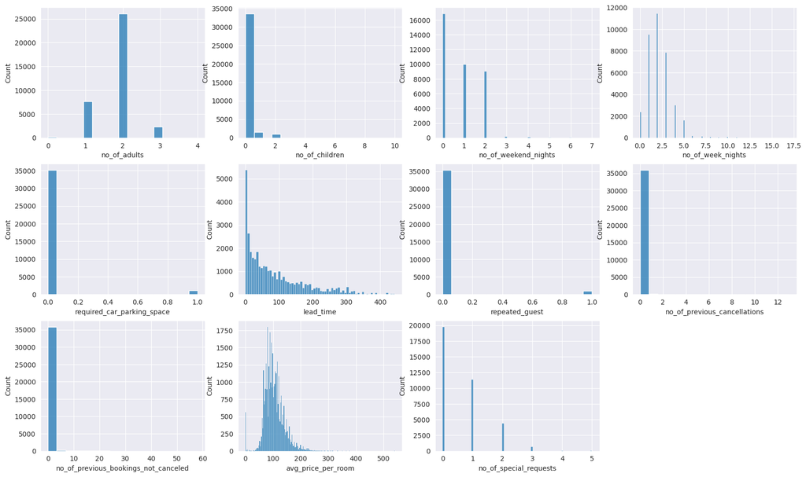

```python
#Creating histograms for numerical variables

plt.figure(figsize=(20, 16))

for i, variable in enumerate(num_cols):
  sns.set_style('darkgrid')
  plt.subplot(4, 4, i+1)
  sns.histplot(data = df, x=df[variable])
plt.show()
```

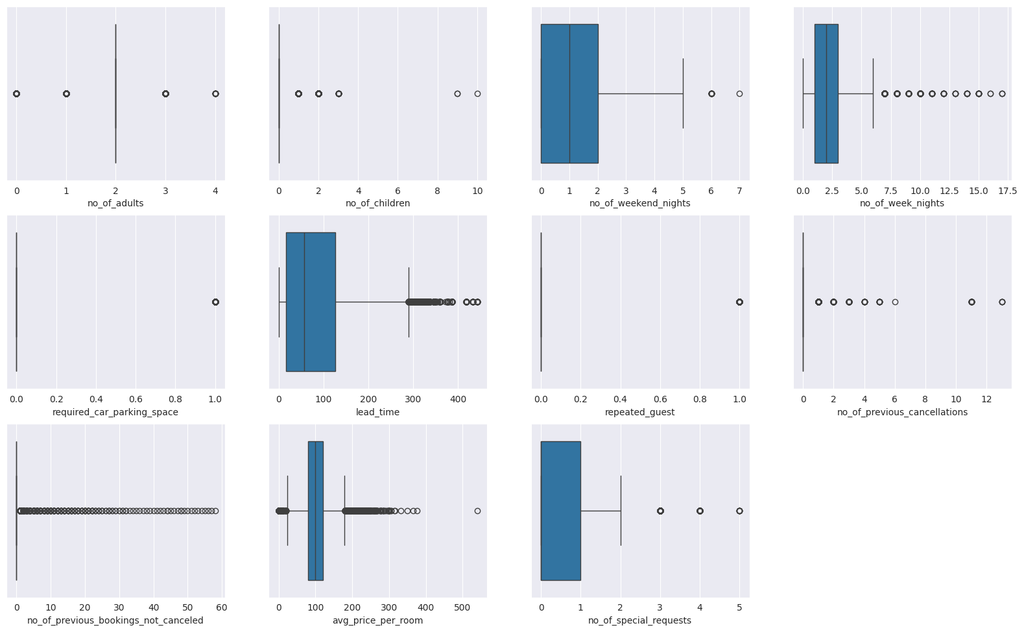

```python
#Creating boxplots for numerical variables

plt.figure(figsize=(20, 16))

for i, variable in enumerate(num_cols):
  sns.set_style('darkgrid')
  plt.subplot(4, 4, i+1)
  sns.boxplot(data = df, x=df[variable])
plt.show()
```

### **Observations:**

- Most of the numerical variables are discrete variables with numbers ranging from 0 to 10.
- We can see from the histograms that lead time is right skewed, which indicates that most customers tend to book their stays closer to or on the check in date. Bookings that are made for over a year in advance are outliers.
- Most bookings have no previous cancelations from the customer, with a few outliers.
- The median average price per room is around 100 dollars.There are a few outliers on both sides of the boxplot which seems to make sense for a hotel. However, there is one observation of over 500 dollars that seems to be out of normal. Let's further verify that.

```python
#Let's calculate the 25th percentile

Q1 = df['avg_price_per_room'].quantile(0.25)
Q1
```

```
np.float64(80.3)
```

```python
#Let's calculate the 75th percentile

Q3 = df['avg_price_per_room'].quantile(0.75)
Q3
```

```
np.float64(120.0)
```

```python
#Calculating IQR

IQR = Q3 - Q1
IQR
```

```
np.float64(39.7)
```

```python
#Calculating the value of the upper whisker

upper = Q3 + 1.5 * IQR
upper
```

```
np.float64(179.55)
```

```python
df['avg_price_per_room'] = df['avg_price_per_room'].apply(lambda x: upper if x > 500 else x)
```

```python
df[df['avg_price_per_room'] > 500]
```

|  | no_of_adults | no_of_children | no_of_weekend_nights | no_of_week_nights | type_of_meal_plan | required_car_parking_space | room_type_reserved | lead_time | arrival_year | arrival_month | arrival_date | market_segment_type | repeated_guest | no_of_previous_cancellations | no_of_previous_bookings_not_canceled | avg_price_per_room | no_of_special_requests | booking_status |
| --- | --- | --- | --- | --- | --- | --- | --- | --- | --- | --- | --- | --- | --- | --- | --- | --- | --- | --- |

```python
#Creating a list for categorical and discrete variables

cat_cols = ['no_of_adults', 'no_of_children', 'no_of_week_nights', 'no_of_weekend_nights', 'required_car_parking_space',
        'type_of_meal_plan', 'room_type_reserved', 'arrival_month', 'market_segment_type', 'no_of_special_requests',
        'booking_status']
```

```python
#Checking the frequency of each label for cat_cols

for variable in cat_cols:
  print(df[variable].value_counts(normalize=True))
  print('-' * 50)
```

```
no_of_adults
2    0.719724
1    0.212130
3    0.063873
0    0.003832
4    0.000441
Name: proportion, dtype: float64
--------------------------------------------------
no_of_children
0     0.925624
1     0.044604
2     0.029166
3     0.000524
9     0.000055
10    0.000028
Name: proportion, dtype: float64
--------------------------------------------------
no_of_week_nights
2     0.315479
1     0.261558
3     0.216099
4     0.082426
0     0.065803
5     0.044493
6     0.005210
7     0.003115
10    0.001709
8     0.001709
9     0.000937
11    0.000469
15    0.000276
12    0.000248
14    0.000193
13    0.000138
17    0.000083
16    0.000055
Name: proportion, dtype: float64
--------------------------------------------------
no_of_weekend_nights
0    0.465114
```

[output cut: 53 more lines]

```
--------------------------------------------------
no_of_special_requests
0    0.545196
1    0.313522
2    0.120303
3    0.018608
4    0.002150
5    0.000221
Name: proportion, dtype: float64
--------------------------------------------------
booking_status
Not_Canceled    0.672364
Canceled        0.327636
Name: proportion, dtype: float64
--------------------------------------------------
```

### **Data Preprocessing**

```python
#Replacing the number of children outliers with the maximum feasible value of number of children (3)

df['no_of_children'] = df['no_of_children'].apply(lambda x: 3 if x == 9 or x == 10 else x)
```

```python
#Encoding the target variable with 1 (Canceled) and 0 (Not Canceled)

df['booking_status'] = df['booking_status'].apply(lambda x: 1 if x == 'Canceled' else 0)
```

```python
df.booking_status.value_counts(normalize=True)
```

| booking_status | proportion |
| --- | --- |
| 0 | 0.672364 |
| 1 | 0.327636 |

**dtype:** float64

### **Bivariate Analysis**

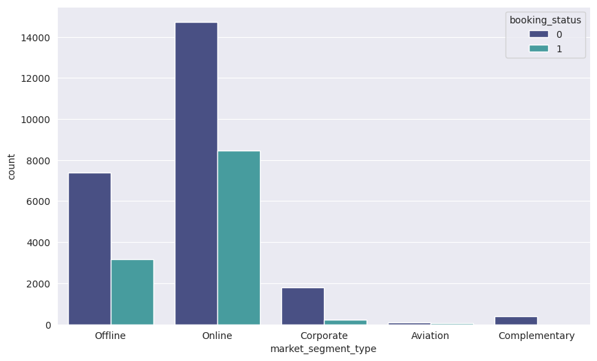

```python
#Let's verify booking status for different market segments

plt.figure(figsize=(10, 6))
sns.countplot(data=df, x='market_segment_type', hue='booking_status', palette='mako')
plt.show()
```

```python
pd.crosstab(df['market_segment_type'], df['booking_status'], normalize = 'index')
```

| booking_status market_segment_type | 0 | 1 |
| --- | --- | --- |
| Aviation | 0.704000 | 0.296000 |
| Complementary | 1.000000 | 0.000000 |
| Corporate | 0.890927 | 0.109073 |
| Offline | 0.700513 | 0.299487 |
| Online | 0.634919 | 0.365081 |

### **Observations:**

- Online bookings have the highest proportion of cancellations, with ~37% of online bookings being cancelled. Offline market has a smaller proportion of cancellations, with 30% of bookings canceled. Corporate and aviation have few bookings with a cancellation rate of 11% and 30%, respectively. Complementary bookings have no cancellations.

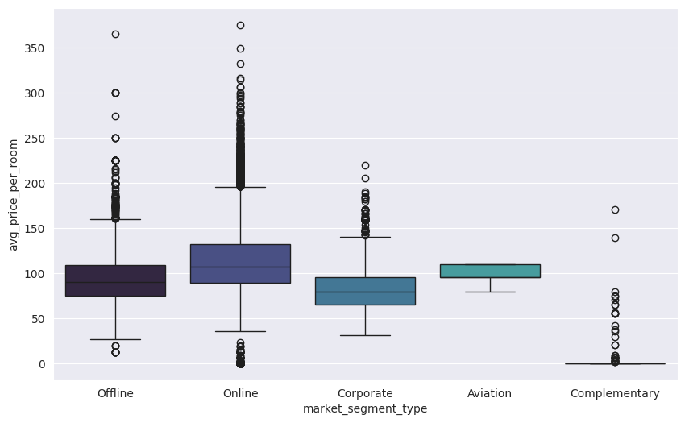

```python
#Let's check the different prices accross accross different market segments

plt.figure(figsize=(10, 6))
sns.boxplot(data=df, x='market_segment_type', y='avg_price_per_room', palette='mako')
plt.show()
```

### **Observations:**

- All segments seem to choose rooms with similar price points, ranging from 80 to 130 dollars. However, the most expensive rooms are normally booked online. Corporate segment seems to prefer rooms with a lower price point.

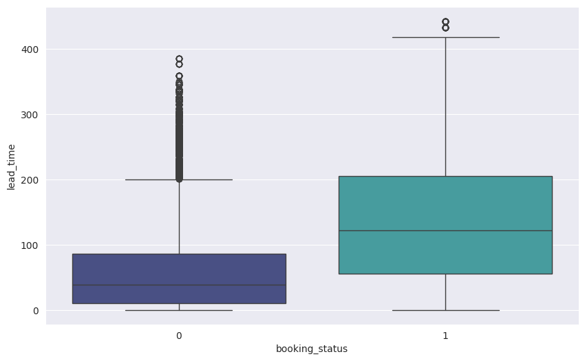

```python
#Verifying the how lead time is distributed for the different booking_status

plt.figure(figsize=(10, 6))
sns.boxplot(data=df, x='booking_status', y='lead_time', palette='mako')
plt.show()
```

### **Observations:**

- As expected, bookings with higher lead times are most prone to cancellations, while bookings made up to 60 days until check in are less prone to cancellations.

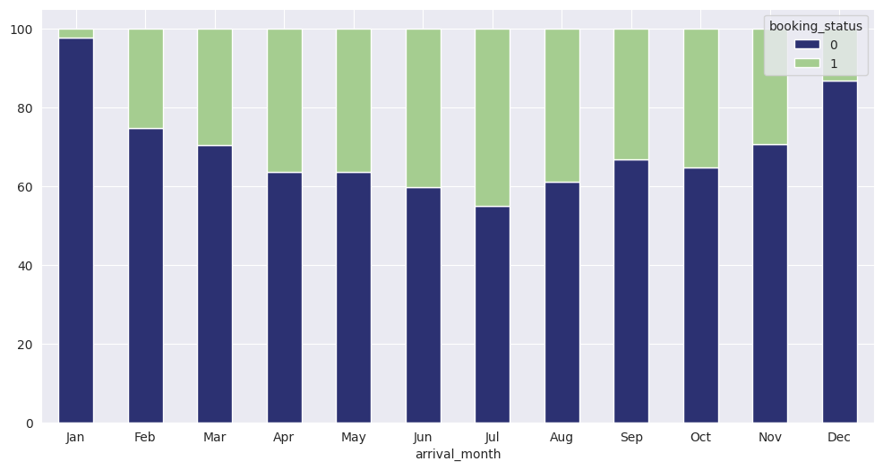

```python
#Let's check how cancellations happened across different months:

g = (pd.crosstab(df['arrival_month'], df['booking_status'], normalize = 'index')*100).plot(kind = 'bar', figsize = (12, 6), stacked = True, colormap = 'crest_r')
g.set_xticklabels(['Jan', 'Feb', 'Mar', 'Apr', 'May', 'Jun', 'Jul', 'Aug', 'Sep', 'Oct', 'Nov', 'Dec'])
plt.xticks(rotation=0)
plt.show()
```

### **Observations:**

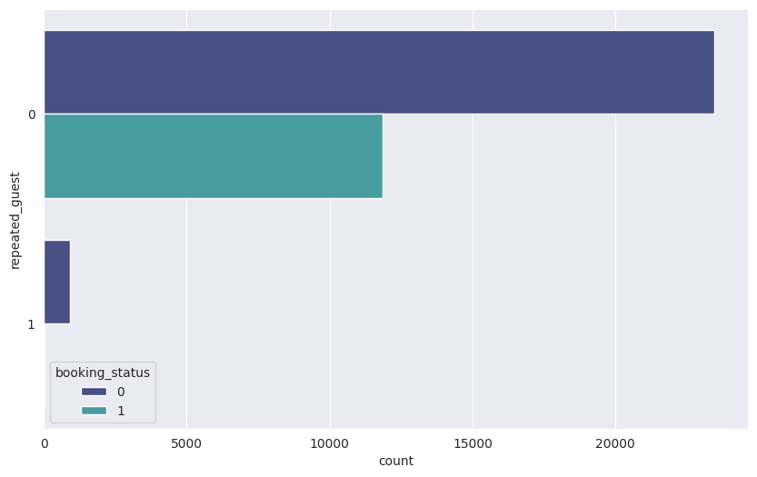

```python
#Let's check how repeated guests behave in terms of cancellations

plt.figure(figsize=(10, 6))
sns.countplot(data=df, y='repeated_guest', hue='booking_status', palette='mako')
plt.show()
```

```python
pd.crosstab(df['repeated_guest'], df['booking_status'])
```

| booking_status repeated_guest | 0 | 1 |
| --- | --- | --- |
| 0 | 23476 | 11869 |
| 1 | 914 | 16 |

### **Observations:**

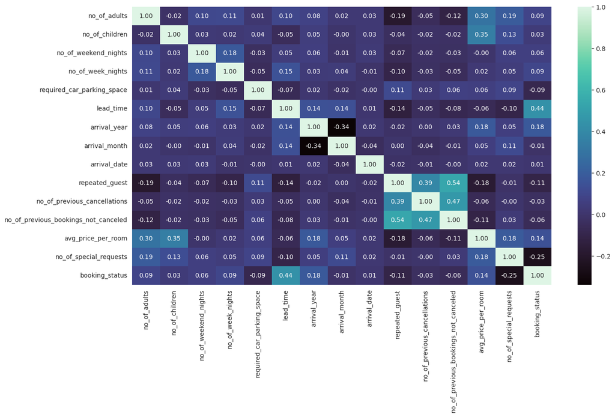

```python
#Let's create a correlation matrix between numerical variables

plt.figure(figsize=(15, 8))

sns.heatmap(df.corr(numeric_only=True), annot=True, fmt='0.2f', cmap='mako')
plt.show()
```

### **Observations:**

# **Model Building**

### **Data preparation for modeling**

```python
# Creating dummy variables

df = pd.get_dummies(data = df, drop_first = True)
```

```python
df.info()
```

```
<class 'pandas.core.frame.DataFrame'>
RangeIndex: 36275 entries, 0 to 36274
Data columns (total 28 columns):
 #   Column                                Non-Null Count  Dtype
---  ------                                --------------  -----
 0   no_of_adults                          36275 non-null  int64
 1   no_of_children                        36275 non-null  int64
 2   no_of_weekend_nights                  36275 non-null  int64
 3   no_of_week_nights                     36275 non-null  int64
 4   required_car_parking_space            36275 non-null  int64
 5   lead_time                             36275 non-null  int64
 6   arrival_year                          36275 non-null  int64
 7   arrival_month                         36275 non-null  int64
 8   arrival_date                          36275 non-null  int64
 9   repeated_guest                        36275 non-null  int64
```

[output cut: 20 more lines]

```python
#Separating the Independent Variables (X) and the Target Variable (Y)

Y = df['booking_status']

X = df.drop(['booking_status'], axis = 1)
```

```python
Y.value_counts(normalize=True)
```

| booking_status | proportion |
| --- | --- |
| 0 | 0.672364 |
| 1 | 0.327636 |

**dtype:** float64

```python
X.info()
```

```
<class 'pandas.core.frame.DataFrame'>
RangeIndex: 36275 entries, 0 to 36274
Data columns (total 27 columns):
 #   Column                                Non-Null Count  Dtype
---  ------                                --------------  -----
 0   no_of_adults                          36275 non-null  int64
 1   no_of_children                        36275 non-null  int64
 2   no_of_weekend_nights                  36275 non-null  int64
 3   no_of_week_nights                     36275 non-null  int64
 4   required_car_parking_space            36275 non-null  int64
 5   lead_time                             36275 non-null  int64
 6   arrival_year                          36275 non-null  int64
 7   arrival_month                         36275 non-null  int64
 8   arrival_date                          36275 non-null  int64
 9   repeated_guest                        36275 non-null  int64
```

[output cut: 19 more lines]

### **Data partition into train and test sets**

```python
# Splitting the data into train and test sets
X_train, X_test, y_train, y_test = train_test_split(X, Y, test_size = 0.30, random_state = 42, stratify= Y)
```

```python
X_train.shape, X_test.shape, y_train.shape, y_test.shape
```

```
((25392, 27), (10883, 27), (25392,), (10883,))
```

```python
y_train.value_counts(normalize=True)
```

| booking_status | proportion |
| --- | --- |
| 0 | 0.672377 |
| 1 | 0.327623 |

**dtype:** float64

### **Decision Tree Model**

```python
#Libraries for Model Building and Model Evaluation

from sklearn.tree import DecisionTreeClassifier

from sklearn import tree

from sklearn.ensemble import RandomForestClassifier

# Metrics to evaluate the model
from sklearn.metrics import confusion_matrix, classification_report,f1_score

from sklearn import metrics
```

```python
#Defining the Decision Tree Model

dtree = DecisionTreeClassifier(random_state=42)
```

```python
# Fitting data to the Decision Tree model

dtree.fit(X_train,y_train)
```

```
DecisionTreeClassifier(random_state=42)
```

### **Model Performance on Training Data**

```python
# Making predictions with the Decision Tree model on the training data

y_pred_train_dtree = dtree.predict(X_train)

y_pred_train_dtree
```

```
array([1, 1, 0, ..., 0, 0, 0])
```

```
              precision    recall  f1-score   support

           0       0.99      1.00      1.00     17073
           1       1.00      0.99      0.99      8319

    accuracy                           0.99     25392
   macro avg       0.99      0.99      0.99     25392
weighted avg       0.99      0.99      0.99     25392
```

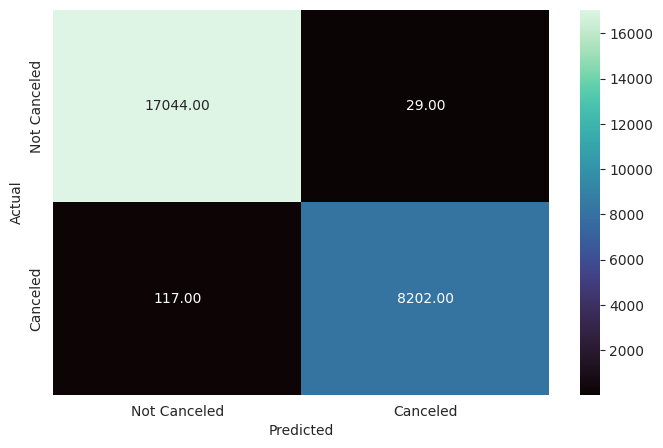

```python
#Creating the confusion matrix to compare y_train and y_predi_train:

print(classification_report(y_train, y_pred_train_dtree))

cm = confusion_matrix(y_train, y_pred_train_dtree)

plt.figure(figsize = (8, 5))

sns.heatmap(cm, annot = True, fmt = '.2f', xticklabels = ['Not Canceled', 'Canceled'], yticklabels = ['Not Canceled', 'Canceled'], cmap= 'mako')

plt.ylabel('Actual')

plt.xlabel('Predicted')

plt.show()
```

- The model performance on the training set seems too good, we will need to check its performance on the test set and verify a possible overfitting.

### **Model Performance on Test Data**

```python
# Making predictions with the Decision Tree model on the test data

y_pred_test_dtree = dtree.predict(X_test)

y_pred_test_dtree
```

```
array([1, 0, 0, ..., 1, 0, 0])
```

```
              precision    recall  f1-score   support

           0       0.90      0.90      0.90      7317
           1       0.79      0.80      0.79      3566

    accuracy                           0.86     10883
   macro avg       0.85      0.85      0.85     10883
weighted avg       0.86      0.86      0.86     10883
```

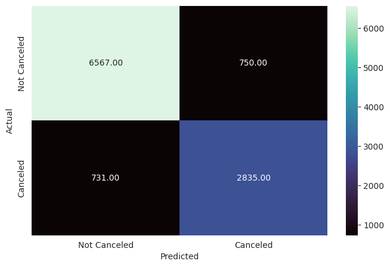

```python
#Creating the confusion matrix to compare y_test and y_pred_test:

print(classification_report(y_test, y_pred_test_dtree))

cm = confusion_matrix(y_test, y_pred_test_dtree)

plt.figure(figsize = (8, 5))

sns.heatmap(cm, annot = True, fmt = '.2f', xticklabels = ['Not Canceled', 'Canceled'], yticklabels = ['Not Canceled', 'Canceled'], cmap= 'mako')

plt.ylabel('Actual')

plt.xlabel('Predicted')

plt.show()
```

### **Observations**

The **model performance** on the test set **highly decreased** when comparing with the training set. We can observe that **this model can not generalize well** on unseen data.

### **Hyperparameter Tuning**

```python
# Library for Hyperparameter Tuning

from sklearn.model_selection import GridSearchCV
```

```python
#Creating another model and changing the proportion of class balance to 0:30% and 1:70%

dtree_ht = DecisionTreeClassifier(random_state = 42, class_weight = {0: 0.3, 1: 0.7})
```

```python
# Grid of parameters to choose from
parameters = {'max_depth': np.arange(2, 10),
              'criterion': ['gini', 'entropy'],
              'min_samples_leaf': [5, 10, 20, 25]
             }
```

```python
# Type of scoring used to compare parameter combinations - f1 score for class 1

scorer = metrics.make_scorer(f1_score, pos_label = 1)
```

```python
# Run the grid search

grid_search = GridSearchCV(dtree_ht,
                        {'max_depth': np.arange(2, 10),
                         'criterion': ['gini', 'entropy'],
                         'min_samples_leaf': [5, 10, 20, 25]},
                        scoring = metrics.make_scorer(f1_score, pos_label = 1),
                        cv = 5)
```

```python
#Fitting the grid object to the train data

grid_search = grid_search.fit(X_train, y_train)
```

```python
# Set the classifier to the best combination of parameters

dtree_ht = grid_search.best_estimator_
```

```python
# Fit the best algorithm to the training data

dtree_ht.fit(X_train, y_train)
```

```
DecisionTreeClassifier(class_weight={0: 0.3, 1: 0.7}, criterion='entropy',
                       max_depth=np.int64(9), min_samples_leaf=5,
                       random_state=42)
```

### **Tuned Model performance on the training and testing data**

```python
# Making predictions using the Tuned Model on the training data
y_pred_train_ht = dtree_ht.predict(X_train)

y_pred_train_ht
```

```
array([1, 1, 1, ..., 0, 0, 1])
```

```
              precision    recall  f1-score   support

           0       0.91      0.88      0.89     17073
           1       0.77      0.81      0.79      8319

    accuracy                           0.86     25392
   macro avg       0.84      0.85      0.84     25392
weighted avg       0.86      0.86      0.86     25392
```

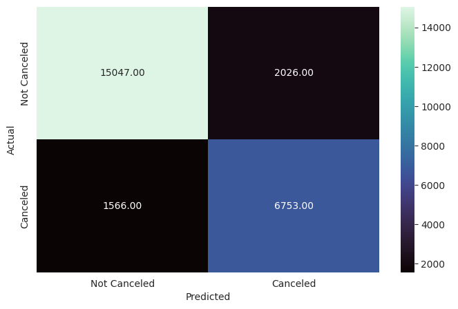

```python
#Creating the confusion matrix to compare y_train and y_pred_train_ht:

print(classification_report(y_train, y_pred_train_ht))

cm = confusion_matrix(y_train, y_pred_train_ht)

plt.figure(figsize = (8, 5))

sns.heatmap(cm, annot = True, fmt = '.2f', xticklabels = ['Not Canceled', 'Canceled'], yticklabels = ['Not Canceled', 'Canceled'], cmap= 'mako')

plt.ylabel('Actual')

plt.xlabel('Predicted')

plt.show()
```

- Before, the Decision Tree model was overfitting the data, we can see that the tuned model helped with the overfitting problem, but we may need to look for better model performance.

```python
# Making predictions using the Tuned Model on the test data
y_pred_test_ht = dtree_ht.predict(X_test)

y_pred_test_ht
```

```
array([1, 0, 0, ..., 1, 1, 0])
```

```
              precision    recall  f1-score   support

           0       0.90      0.87      0.89      7317
           1       0.75      0.81      0.78      3566

    accuracy                           0.85     10883
   macro avg       0.83      0.84      0.83     10883
weighted avg       0.85      0.85      0.85     10883
```

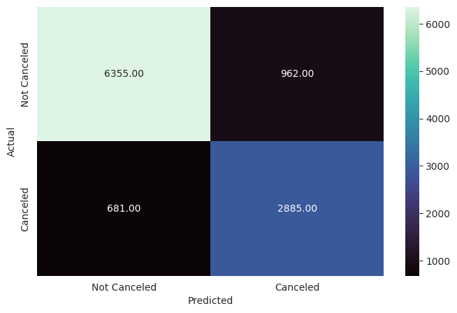

```python
#Creating the confusion matrix to compare y_test and y_pred_test_ht:

print(classification_report(y_test, y_pred_test_ht))

cm = confusion_matrix(y_test, y_pred_test_ht)

plt.figure(figsize = (8, 5))

sns.heatmap(cm, annot = True, fmt = '.2f', xticklabels = ['Not Canceled', 'Canceled'], yticklabels = ['Not Canceled', 'Canceled'], cmap= 'mako')

plt.ylabel('Actual')

plt.xlabel('Predicted')

plt.show()
```

### **Observations**:

- We can see that the tuned model is generalizing well on unseen data.
- The model predicted that 681 bookings would not be cancelled, that were actually cancelled, which could impact profitability. On the other hand, it predicted that 962 bookings were going to be cancelled, that ended up not being cancelled, which could also hurt the business for targeting the wrong individuals.
- If the idea is to build a predictive model that can predict which booking is going to be canceled in advance, and help in formulating profitable policies for cancellations and refunds; it is essential to increase the predictive performance of the model, so impacts to profit can be minimized.

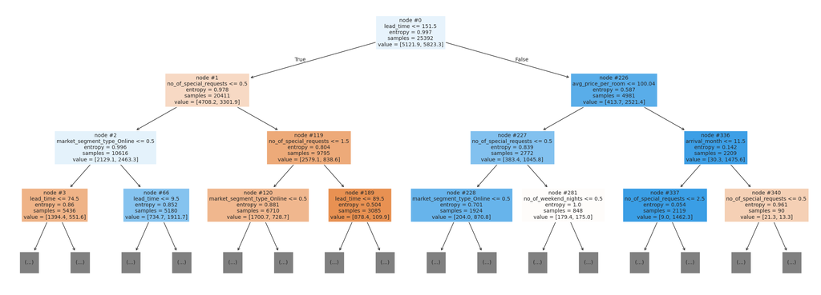

```python
#Plotting the decision tree

features = list(X.columns)

plt.figure(figsize=(28,10))

tree.plot_tree(dtree_ht, max_depth=3, feature_names=features, filled=True, fontsize=10, node_ids=True, class_names=None);

plt.show()
```

### **Observations:**

- The orange nodes represent the class majority of 'not cancelled' (0), while the blue nodes represent the class majority of 'cancelled' (1).
- Decision Trees have the advantage of better explainability, and we can see on the first decision node that lead time is one of the most important features on predicting if a booking will be cancelled or not.
- As expected, for lead times greater than 150 days, the chances that a booking will be cancelled is increased.

### **Feature Importance**

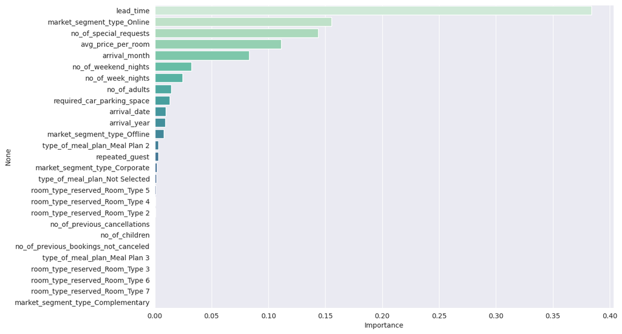

```python
# Plotting the feature importance

importances = dtree_ht.feature_importances_

columns = X.columns;

importance_bookings = pd.DataFrame(importances, index=columns, columns=['Importance']).sort_values(by='Importance', ascending=False);

plt.figure(figsize=(12,8));

sns.barplot(x=importance_bookings.Importance,y= importance_bookings.index, hue=importance_bookings.index, palette='mako_r');

plt.show()

#print(importance_bookings)
```

```python
print(importance_bookings)
```

```
                                      Importance
lead_time                               0.384041
market_segment_type_Online              0.155330
no_of_special_requests                  0.143508
avg_price_per_room                      0.111028
arrival_month                           0.082901
no_of_weekend_nights                    0.032136
no_of_week_nights                       0.024370
no_of_adults                            0.014360
required_car_parking_space              0.013280
arrival_date                            0.009734
arrival_year                            0.009129
market_segment_type_Offline             0.007979
type_of_meal_plan_Meal Plan 2           0.003370
repeated_guest                          0.003131
market_segment_type_Corporate           0.001863
type_of_meal_plan_Not Selected          0.001429
room_type_reserved_Room_Type 5          0.001080
room_type_reserved_Room_Type 4          0.000822
room_type_reserved_Room_Type 2          0.000508
no_of_previous_cancellations            0.000000
no_of_children                          0.000000
no_of_previous_bookings_not_canceled    0.000000
type_of_meal_plan_Meal Plan 3           0.000000
room_type_reserved_Room_Type 3          0.000000
room_type_reserved_Room_Type 6          0.000000
room_type_reserved_Room_Type 7          0.000000
market_segment_type_Complementary       0.000000
```

### **Observations:**

- We can see that lead_time, market_segment_type_Online, no_of_special_requests, avg_price_per_room, and arrival_month are the most important features for predicting whether a booking will be cancelled or not.
- Other variables such as no_of_weekend_nights, no_of_week_nights, and no_of_adults have some importance for the predictive model to make predictions.
- Interestingly, no_of_previous_cancellations did not present any importance for the model to predict bookings cancellations.

### **Random Forest Model**

The random forest classifier has the benefit of presenting a **better generalization and improved accuracy** when compared to the decision tree classifier as it combines multiple decision trees through ensemble learning. However, **random forests can be less interpretable**, require more computation, and can be slower to train and predict compared to a single decision trree.

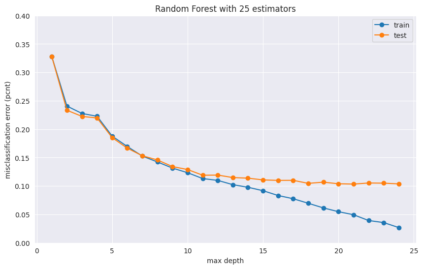

```python
#Creating the Random Forest Model

train_scores = []

test_scores = []

for depth in range(1, 25):

    rf = RandomForestClassifier(random_state = 42, criterion = 'entropy', max_depth = depth, n_estimators = 25)

    rf = rf.fit(X_train, y_train)

    train_scores.append(1 - rf.score(X_train, y_train))

    test_scores.append(1 - rf.score(X_test, y_test))

plt.plot(range(1, 25), train_scores, '-o', label = "train")

plt.plot(range(1, 25), test_scores, '-o', label = "test")

plt.legend(loc = 'upper right')

plt.xlabel('max depth')

plt.ylim(0, 0.4)

plt.ylabel('misclassification error (pcnt)')

plt.title(f"Random Forest with 25 estimators")

fig = plt.gcf()

fig.set_size_inches(10, 6)

plt.show()
```

- We can see that after as we increase the model tends to overfit and the test error does not change much. Let's try creating a random forest model with max_depth = 20 to see if we can minimize the test error.

```python
#Creating a Random Forest model with max_depth = 11

rf_model = RandomForestClassifier(random_state = 42, criterion = "entropy", max_depth = 20, n_estimators = 25)

rf_model.fit(X_train, y_train)
```

```
RandomForestClassifier(criterion='entropy', max_depth=20, n_estimators=25,
                       random_state=42)
```

### **RF Model Performance on Training and Test Data**

```python
# Checking performance on the training data
y_pred_train_rf = rf_model.predict(X_train)

y_pred_train_rf
```

```
array([1, 1, 0, ..., 0, 0, 0])
```

```
              precision    recall  f1-score   support

           0       0.95      0.97      0.96     17073
           1       0.93      0.90      0.91      8319

    accuracy                           0.95     25392
   macro avg       0.94      0.93      0.94     25392
weighted avg       0.94      0.95      0.94     25392
```

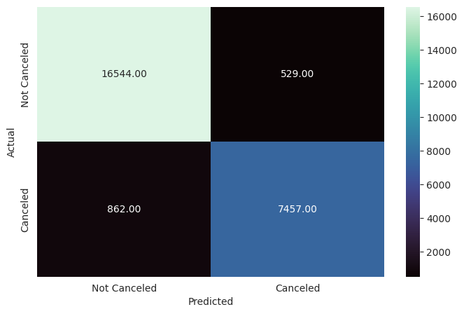

```python
#Creating the confusion matrix to compare y_train and y_pred_train_rf:

print(classification_report(y_train, y_pred_train_rf))

cm = confusion_matrix(y_train, y_pred_train_rf)

plt.figure(figsize = (8, 5))

sns.heatmap(cm, annot = True, fmt = '.2f', xticklabels = ['Not Canceled', 'Canceled'], yticklabels = ['Not Canceled', 'Canceled'], cmap= 'mako')

plt.ylabel('Actual')

plt.xlabel('Predicted')

plt.show()
```

- This Random Forest Model is performing well on the training data. Let's see how it will perform on the test data.

```python
# Creating predictions on the testing data

y_pred_test_rf = rf_model.predict(X_test)

y_pred_test_rf
```

```
array([1, 0, 0, ..., 1, 0, 0])
```

```
              precision    recall  f1-score   support

           0       0.91      0.94      0.92      7317
           1       0.86      0.81      0.84      3566

    accuracy                           0.90     10883
   macro avg       0.89      0.87      0.88     10883
weighted avg       0.90      0.90      0.90     10883
```

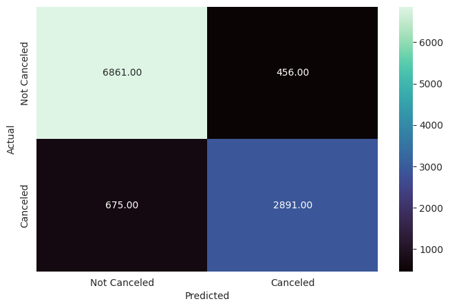

```python
#Creating the confusion matrix to compare y_test and y_pred_test_rf:

print(classification_report(y_test, y_pred_test_rf))

cm = confusion_matrix(y_test, y_pred_test_rf)

plt.figure(figsize = (8, 5))

sns.heatmap(cm, annot = True, fmt = '.2f', xticklabels = ['Not Canceled', 'Canceled'], yticklabels = ['Not Canceled', 'Canceled'], cmap= 'mako')

plt.ylabel('Actual')

plt.xlabel('Predicted')

plt.show()
```

# **Observations**:

- We can see that the Random Forest model had better accuracy (~90%) on making predictions on the test data compared to the decision tree and tuned decision tree models. It also seems to have reduced the overfitting problem and it is generalizing well on unseen data.
- Because we want a balance between correctly identifying the positive class, while avoiding false positives, the F1-score is also increased when compared to the other models.
- Let's try Hyperparameter Tuning on the Random forest model.

### **Hyperparameter Tuning - Random Forest**

```python
# Creating a general rf classifier

rf_model_tuned = RandomForestClassifier(criterion = "entropy", random_state = 42)
```

```python
# Run the grid search
grid_rf = GridSearchCV(rf_model_tuned,
                       {"n_estimators": [25, 30],
                        "max_depth": [15, 20],
                         "min_samples_leaf": [20, 25],
                          "max_features": [0.8, 0.9],
                           "max_samples": [0.9, 1],
                             "class_weight" : ["balanced",{0: 0.3, 1: 0.7}]},
                       scoring = metrics.make_scorer(f1_score, pos_label = 1),
                       cv = 5)

grid_rf = grid_rf.fit(X_train, y_train)
```

```python
# Set the model to the best combination of parameters

rf_model_tuned = grid_rf.best_estimator_
```

```python
# Fitting the best algorithm to the training data

rf_model_tuned.fit(X_train, y_train)
```

```
RandomForestClassifier(class_weight='balanced', criterion='entropy',
                       max_depth=15, max_features=0.8, max_samples=0.9,
                       min_samples_leaf=20, n_estimators=30, random_state=42)
```

### **RF Tuned Model Performance on the Training and Test Data**

```python
#Making predictions on the training data

y_pred_train_rft = rf_model_tuned.predict(X_train)
```

```
              precision    recall  f1-score   support

           0       0.93      0.90      0.91     17073
           1       0.81      0.86      0.83      8319

    accuracy                           0.89     25392
   macro avg       0.87      0.88      0.87     25392
weighted avg       0.89      0.89      0.89     25392
```

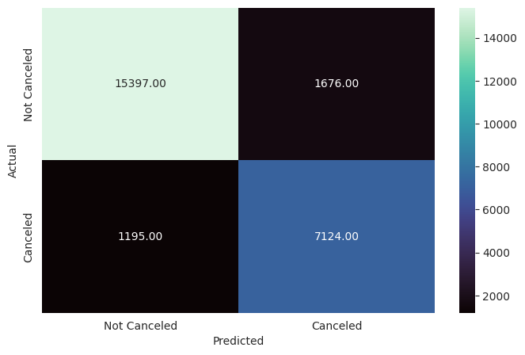

```python
#Creating the confusion matrix to compare y_train and y_pred_train_rft:

print(classification_report(y_train, y_pred_train_rft))

cm = confusion_matrix(y_train, y_pred_train_rft)

plt.figure(figsize = (8, 5))

sns.heatmap(cm, annot = True, fmt = '.2f', xticklabels = ['Not Canceled', 'Canceled'], yticklabels = ['Not Canceled', 'Canceled'], cmap= 'mako')

plt.ylabel('Actual')

plt.xlabel('Predicted')

plt.show()
```

```python
#Making predictions on the test data

y_pred_test_rft = rf_model_tuned.predict(X_test)
```

```
              precision    recall  f1-score   support

           0       0.92      0.89      0.91      7317
           1       0.79      0.84      0.81      3566

    accuracy                           0.87     10883
   macro avg       0.85      0.87      0.86     10883
weighted avg       0.88      0.87      0.88     10883
```

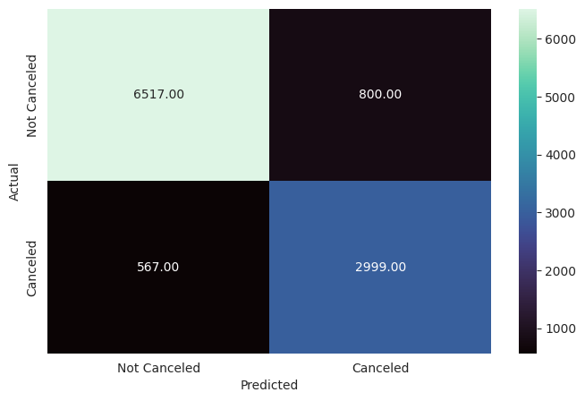

```python
#Creating the confusion matrix to compare y_test and y_pred_test_rft:

print(classification_report(y_test, y_pred_test_rft))

cm = confusion_matrix(y_test, y_pred_test_rft)

plt.figure(figsize = (8, 5))

sns.heatmap(cm, annot = True, fmt = '.2f', xticklabels = ['Not Canceled', 'Canceled'], yticklabels = ['Not Canceled', 'Canceled'], cmap= 'mako')

plt.ylabel('Actual')

plt.xlabel('Predicted')

plt.show()
```

### **Observations:**

- The Random Forest Tuned model seems to generalize very well, but performed worse when compared to the Random Forest model.
- If the idea was reducing the number of False Negatives only, this model would be considered a better model compared to the others, but in this case we need a balance on the prediction errors.

# **Conclusions and Recommendations**

The analysis demonstrates that machine learning can effectively predict hotel booking cancellations and guide targeted operational policies. The base Random Forest model achieved the strongest overall performance, with an accuracy of 90%, an F1 score of 84% for canceled bookings, and balanced precision-recall for non-canceled bookings (precision 91%, recall 94%). Although the tuned Random Forest reduced false negatives slightly (567 vs 675), it increased false positives significantly (800 vs 456), making the base model more reliable for day-to-day decision-making.

Business Recommendations:

By integrating the Random Forest model into operations, the hotel can minimize financial losses from cancellations, optimize resource management, and implement targeted policies that enhance profitability while maintaining guest satisfaction.